# Using {dhhstheme}

Will Mackey

13/10/2020

# The `dhhstheme` package

The `dhhstheme` package is designed to make it easier to generate DHHS-style charts using the `ggplot2` package in R.

# Set up

The package is hosted on Github. To install a package from Github, use the `install_github()` function from the `remotes` package:

```r
install.packages("remotes")
remotes::install_github("wfmackey/dhhstheme")
```

Then load the package, along with the `tidyverse` package that contains `ggplot2` and other data-manipulation tools:

```r
library(dhhstheme)
library(tidyverse)
```

The package contains some COVID-19 data from [Our World in Data](https://ourworldindata.org/coronavirus) for demonstrations. This is loaded with the package in `owid_sample`:

```r
glimpse(owid_sample)
```

```
## Rows: 1,719
## Columns: 12
## $ country                  <chr> "Australia", "Australia", "Australia", "Aust…
## $ continent                <chr> "Oceania", "Oceania", "Oceania", "Oceania", …
## $ date                     <date> 2019-12-31, 2020-01-01, 2020-01-02, 2020-01…
## $ new_cases                <dbl> 0, 0, 0, 0, 0, 0, 0, 0, 0, 0, 0, 0, 0, 0, 0,…
## $ new_deaths               <dbl> 0, 0, 0, 0, 0, 0, 0, 0, 0, 0, 0, 0, 0, 0, 0,…
## $ new_cases_per_million    <dbl> 0.000, 0.000, 0.000, 0.000, 0.000, 0.000, 0.…
## $ new_deaths_per_million   <dbl> 0, 0, 0, 0, 0, 0, 0, 0, 0, 0, 0, 0, 0, 0, 0,…
## $ total_cases              <dbl> 0, 0, 0, 0, 0, 0, 0, 0, 0, 0, 0, 0, 0, 0, 0,…
## $ total_deaths             <dbl> 0, 0, 0, 0, 0, 0, 0, 0, 0, 0, 0, 0, 0, 0, 0,…
## $ total_cases_per_million  <dbl> 0.000, 0.000, 0.000, 0.000, 0.000, 0.000, 0.…
## $ total_deaths_per_million <dbl> 0, 0, 0, 0, 0, 0, 0, 0, 0, 0, 0, 0, 0, 0, 0,…
## $ start_of_month           <lgl> FALSE, FALSE, FALSE, FALSE, FALSE, FALSE, FA…
```

## A basic bar chart using `theme_dhhs`

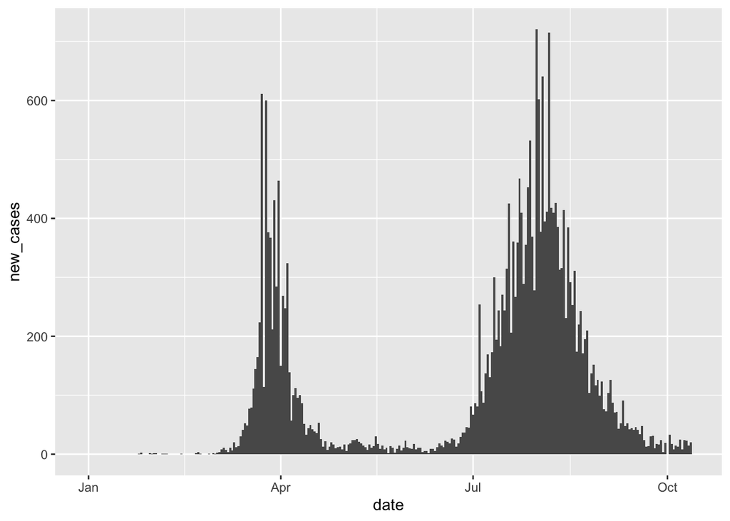

```r
owid_sample %>%
  filter(country == "Australia") %>%
  ggplot(aes(date, new_cases)) +
  geom_col(width = 1)
```

To add the DHHS theme, add `theme_dhhs`:

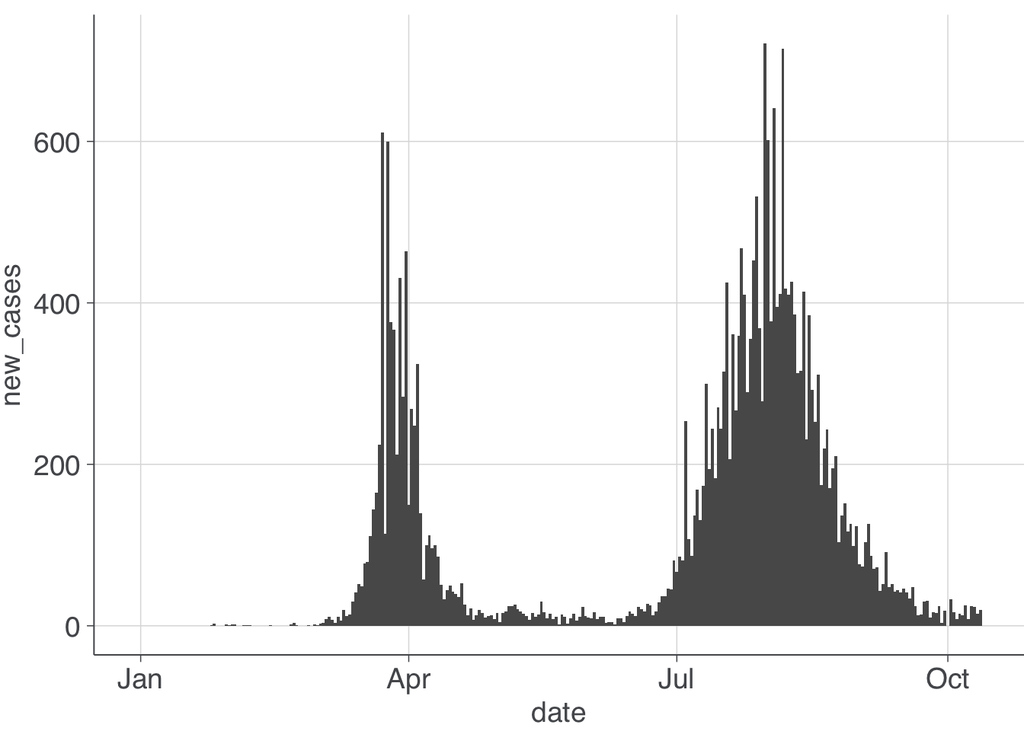

```r
owid_sample %>%
  filter(country == "Australia") %>%
  ggplot(aes(date, new_cases)) +
  geom_col(width = 1) +
  theme_dhhs()
```

You can use the pre-set DHHS colours to `fill` the plot:

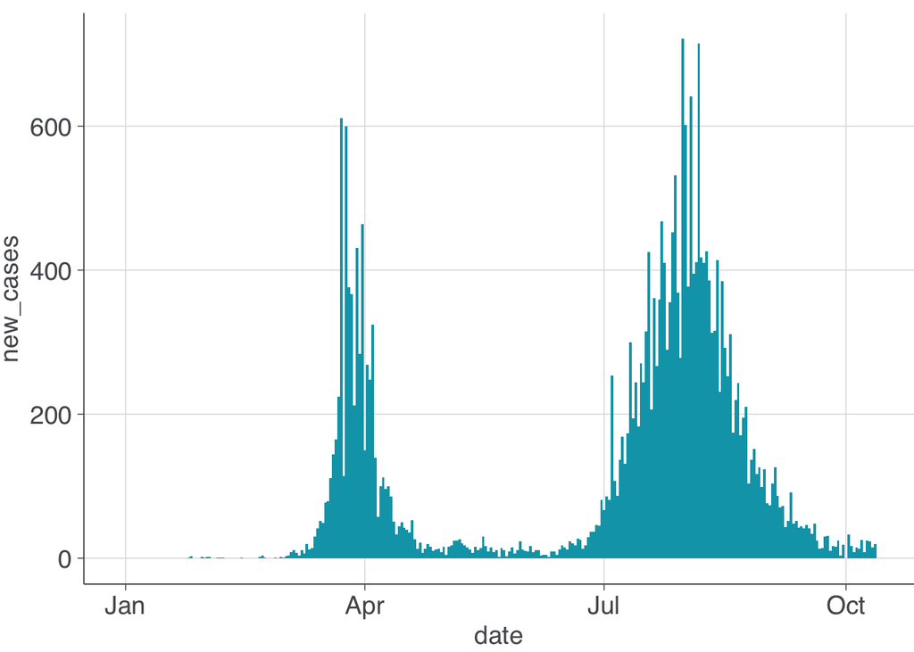

```r
owid_sample %>%
  filter(country == "Australia") %>%
  ggplot(aes(date, new_cases)) +
  geom_col(width = 1,
           fill = dhhs_teal) +
  theme_dhhs()
```

Finally, adding titles and labels:

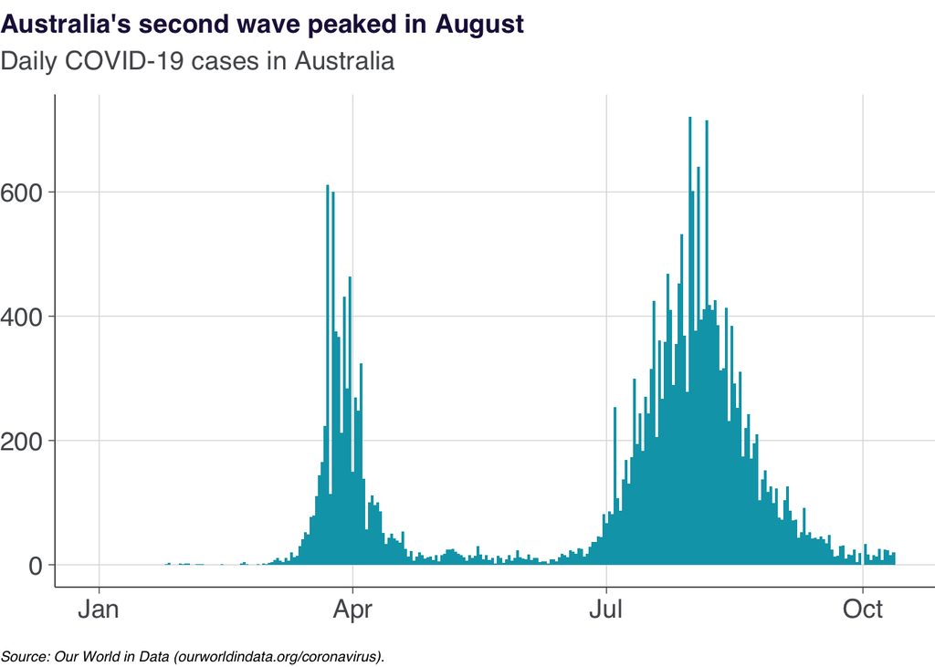

```r
aus_cases <- owid_sample %>%
  filter(country == "Australia") %>%
  ggplot(aes(date, new_cases)) +
  geom_col(width = 1,
           fill = dhhs_teal) +
  theme_dhhs() +
  labs(title = "Australia's second wave peaked in August",
       subtitle = "Daily COVID-19 cases in Australia",
       x = NULL,
       y = NULL,
       caption = "Source: Our World in Data (ourworldindata.org/coronavirus).")

aus_cases
```

## Saving a chart

The `dhhs_save` function

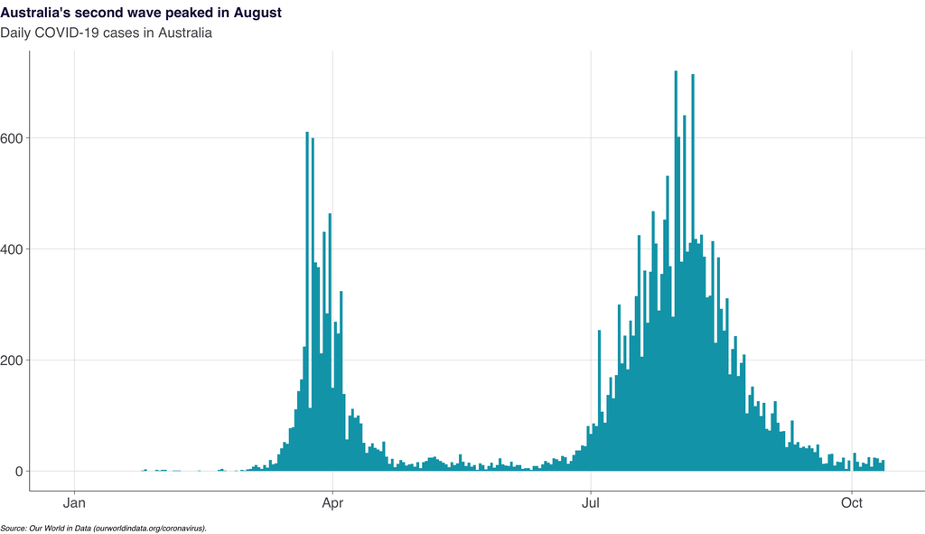

```r
dhhs_save(file_path = "data-raw/aus_cases.png",
          plot_object = aus_cases)
```

- `"whole"`: The default. Use for a plot covering the whole body of a normal DHHS slide. Width: 32.74cm, height: 18.9cm.
- `"half"`:Use for a tall plot covering the full left or right side a normal DHHS slide. Width: 15.65cm, height: 18.9cm.
- `"third"`:Use for a tall plot covering roughly one-third of the horizontal space on a normal DHHS slide.Width: 10cm, height: 18.9cm.
- `"short-whole"`: Use for a short plot covering half the body of a normal DHHS slide. Width: 32.74cm, height: 9.5cm.
- `"short-half"`: Use for a short plot covering half of the left or right side of a normal DHHS slide. Width: 15.65cm, height: 9.5cm.
- `"short-third"`: Use for a short plot covering roughly one-third of the horizontal space on a normal DHHS slide. Width: 10cm, height: 9.5cm.
- `"all"`: Export all of the above in a folder called `file_path`.

For example:

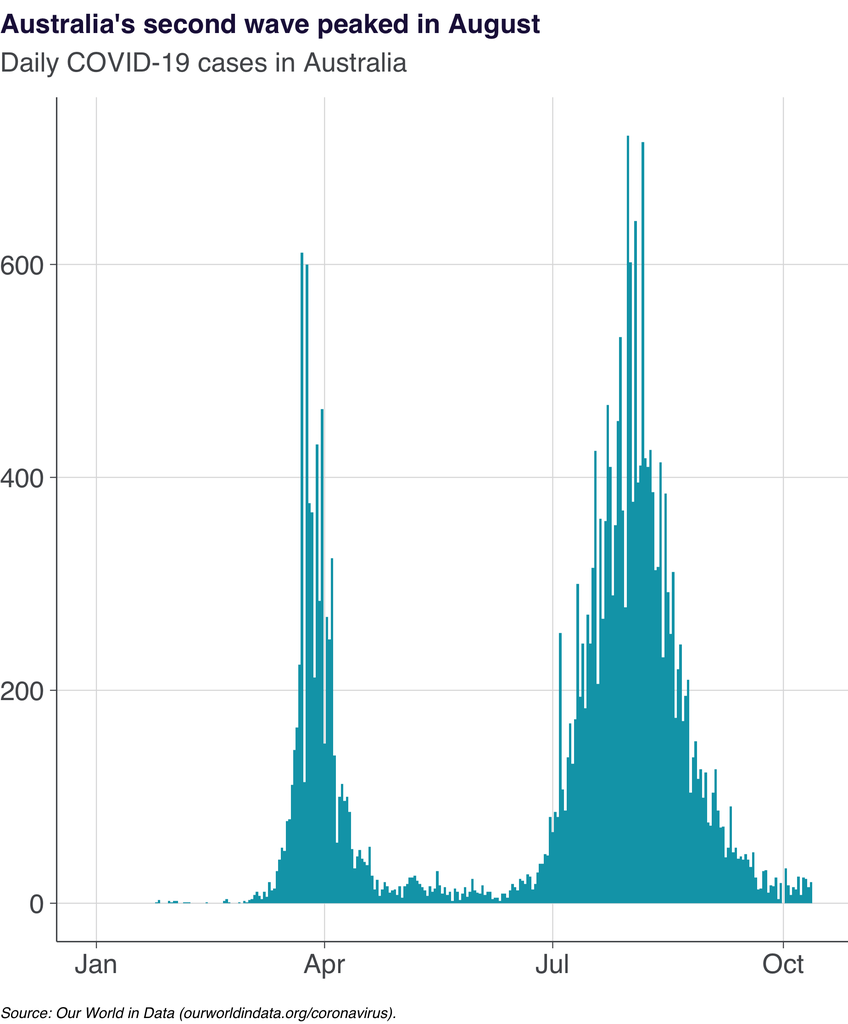

```r
dhhs_save(file_path = "data-raw/aus_cases_half.png",
          plot_object = aus_cases,
          type = "half")
```

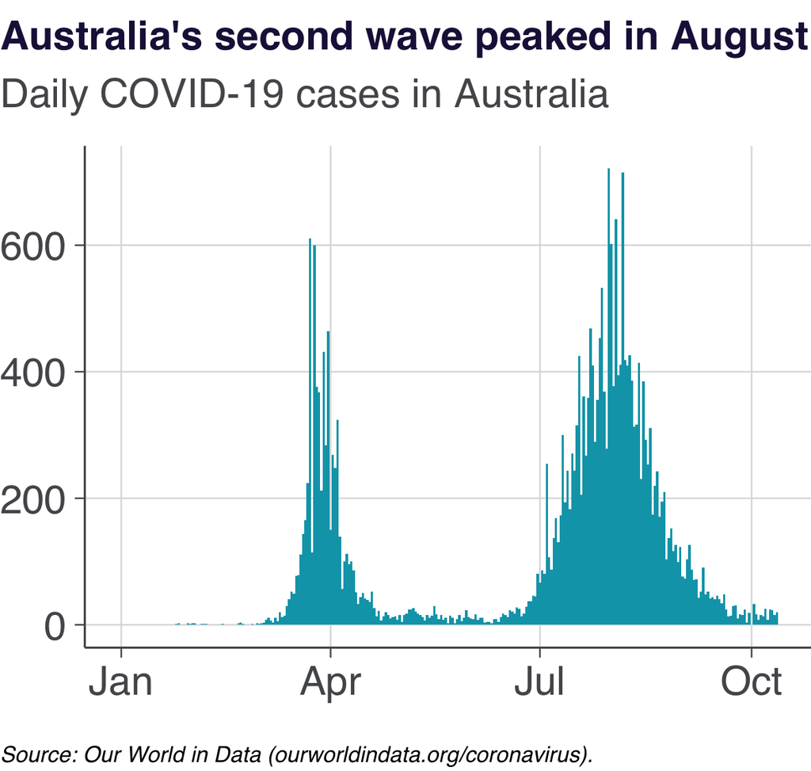

```r
dhhs_save(file_path = "data-raw/aus_cases_short-third.png",
          plot_object = aus_cases,
          type = "short-third")
```

# misc

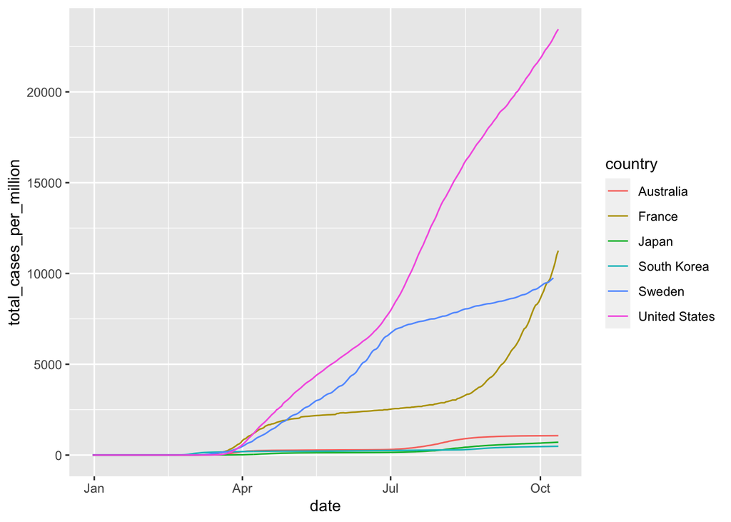

```r
p_base_line <- owid_sample %>%
  ggplot(aes(date, total_cases_per_million,
             colour = country)) +
  geom_line()

p_base_line
```

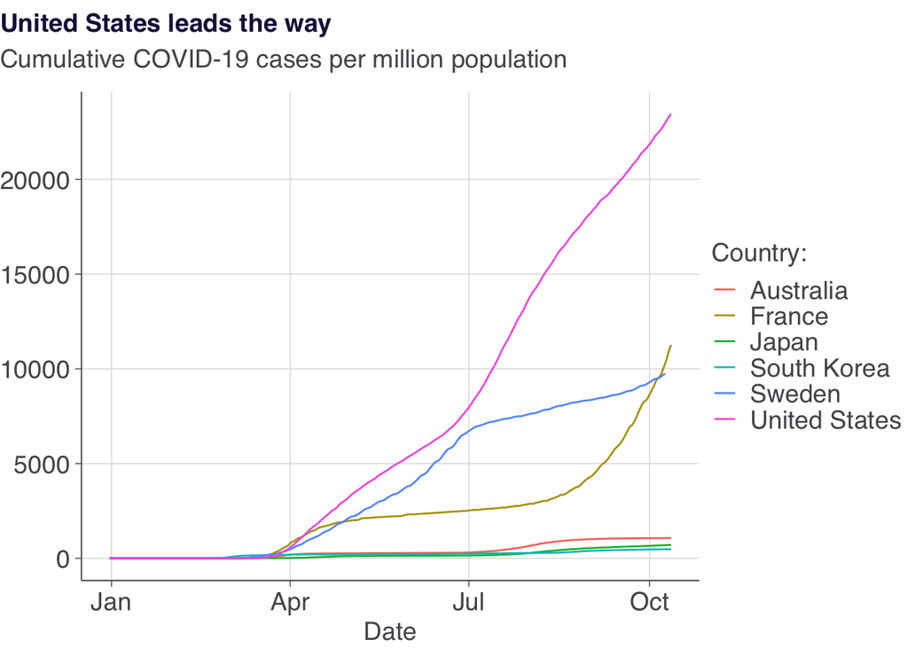

```r
p_base_line +
  theme_dhhs() +
  labs(title = "United States leads the way",
       subtitle = "Cumulative COVID-19 cases per million population",
       x = "Date",
       y = NULL,
       colour = "Country:")
```

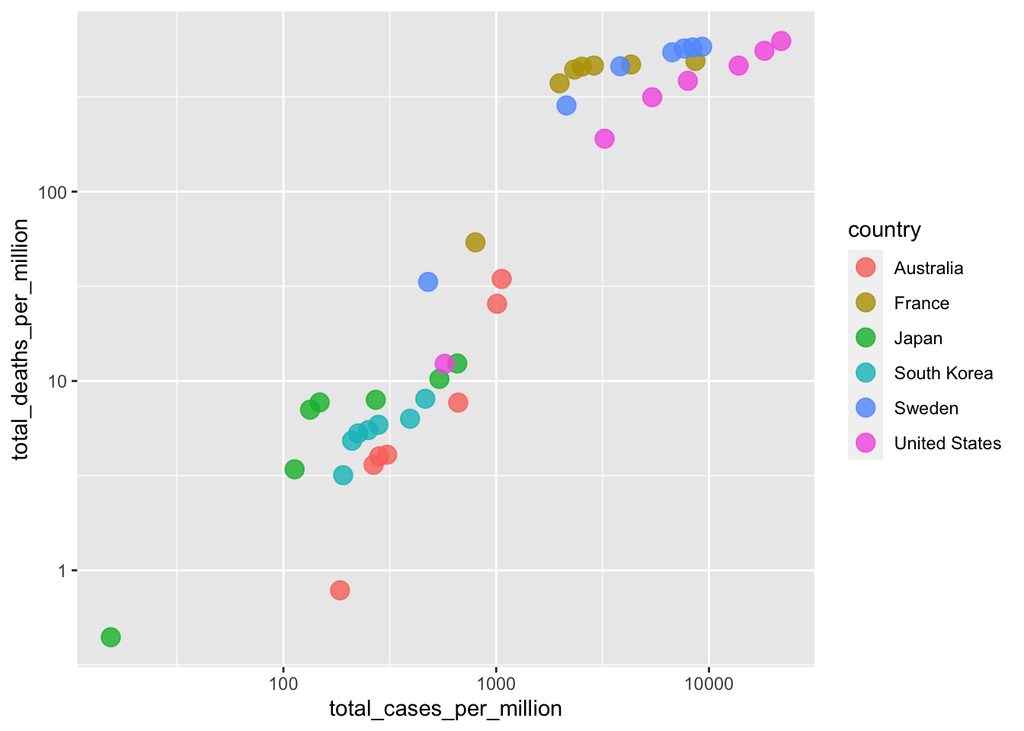

```r
p_base_point <- owid_sample %>%
  filter(start_of_month) %>%
  ggplot(aes(total_cases_per_million, total_deaths_per_million,
             colour = country)) +
  geom_point(size = 4, alpha = .8) +
  scale_x_log10() +
  scale_y_log10()

p_base_point
```